# Foundations of Data Science Project - Diabetes Analysis

## Context

Diabetes is one of the most frequent diseases worldwide and the number of diabetic patients are growing over the years. The main cause of diabetes remains unknown, yet scientists believe that both genetic factors and environmental lifestyle play a major role in diabetes.

A few years ago research was done on a tribe in America which is called the Pima tribe. In this tribe, it was found that the ladies are prone to diabetes very early. Several constraints were placed on the selection of these instances from a larger database. In particular, all patients were females at least 21 years old of Pima tribe.

## Objective

Here, we are analyzing different aspects of Diabetes in the Pima Diabetes Analysis by doing Exploratory Data Analysis.

## Data Dictionary

The dataset has the following information:

- Pregnancies: Number of times pregnant
- Glucose: Plasma glucose concentration over 2 hours in an oral glucose tolerance test
- BloodPressure: Diastolic blood pressure (mm Hg)
- SkinThickness: Triceps skin fold thickness (mm)
- Insulin: 2-Hour serum insulin (mu U/ml)
- BMI: Body mass index (weight in kg/(height in m)^2)
- DiabetesPedigreeFunction: A function that scores the likelihood of diabetes based on family history.
- Age: Age in years
- Outcome: Class variable (0: a person is not diabetic or 1: a person is diabetic)

## Q 1: Import the necessary libraries and briefly explain the use of each library (3 Marks)

```python
# remove _____ & write the appropriate library name

import numpy as np
import pandas as pd

import seaborn as sns
import matplotlib.pyplot as plt
%matplotlib inline

# This code (%matplotlib inline) allows for Matplotlib plots to be displayed within this notebook. Reference: https://www.statology.org/matplotlib-inline/

# Each library is downloaded to allow for exploratory data analysis to occur.
```

#### Write your Answer here:

Ans 1: 1. numpy - The first missing word is - numpy - which makes it 'import numpy as np'. In Python, NumPy is a library used for scientific computing on arrays, i.e., mathematical operations and shape manipulation. Reference: https://numpy.org/doc/stable/user/whatisnumpy.html 2. pandas - This open-source library, that is built on top of NumPy, makes it easy to work with relational / labeled data. Reference: https://www.geeksforgeeks.org/introduction-to-pandas-in-python/ 3. seaborn - This visualization library, that is built on top of matplotlib, allows for the plotting of statistical graphics. Reference: https://www.geeksforgeeks.org/introduction-to-seaborn-python/ 4. matplotlib.pyplot - The second missing word is - matplotlib.pyplot - which makes it 'import matplotlib.pyplot as plt'. matplotlib.pyplot allows for MATLAB-like plotting and opens figures. Reference: https://matplotlib.org/stable/api/pyplot_summary.html

## Q 2: Read the given dataset (1 Mark)

```python
# remove _____ & write the appropriate function name

pima = pd.read_csv("diabetes.csv")

# In order to reach a CSV file, it is necessary to use the following code: pd.read_csv(filename)

# Reference: https://elitedatascience.com/python-cheat-sheet
```

## Q3. Show the last 10 records of the dataset. How many columns are there? (1 Mark)

```python
# remove ______ and write the appropriate number in the function

pima.tail(10)

# In order to show the last 10 records of the dataset, it is necessary to use the following the Pandas tail() method. Since the default return is 5, the number 10 is inserted to view the last 10 records.

# Reference: https://www.geeksforgeeks.org/python-pandas-dataframe-series-tail-method/
```

|  | Pregnancies | Glucose | BloodPressure | SkinThickness | Insulin | BMI | DiabetesPedigreeFunction | Age | Outcome |
| --- | --- | --- | --- | --- | --- | --- | --- | --- | --- |
| 758 | 1 | 106 | 76 | 20 | 79 | 37.5 | 0.197 | 26 | 0 |
| 759 | 6 | 190 | 92 | 20 | 79 | 35.5 | 0.278 | 66 | 1 |
| 760 | 2 | 88 | 58 | 26 | 16 | 28.4 | 0.766 | 22 | 0 |
| 761 | 9 | 170 | 74 | 31 | 79 | 44.0 | 0.403 | 43 | 1 |
| 762 | 9 | 89 | 62 | 20 | 79 | 22.5 | 0.142 | 33 | 0 |
| 763 | 10 | 101 | 76 | 48 | 180 | 32.9 | 0.171 | 63 | 0 |
| 764 | 2 | 122 | 70 | 27 | 79 | 36.8 | 0.340 | 27 | 0 |
| 765 | 5 | 121 | 72 | 23 | 112 | 26.2 | 0.245 | 30 | 0 |
| 766 | 1 | 126 | 60 | 20 | 79 | 30.1 | 0.349 | 47 | 1 |
| 767 | 1 | 93 | 70 | 31 | 79 | 30.4 | 0.315 | 23 | 0 |

#### Write your Answer here:

Ans 3: There are 9 columns.

## Q4. Show the first 10 records of the dataset (1 Mark)

```python
# remove _____ & write the appropriate function name and the number of rows to get in the output

pima.head(10)

# In order to show the first 10 records of the dataset, it is necessary to use the Pandas head() method. Since the default return is 5, the number 10 is inserted to return the first 10 records.

# Reference: https://www.geeksforgeeks.org/python-pandas-dataframe-series-head-method/
```

|  | Pregnancies | Glucose | BloodPressure | SkinThickness | Insulin | BMI | DiabetesPedigreeFunction | Age | Outcome |
| --- | --- | --- | --- | --- | --- | --- | --- | --- | --- |
| 0 | 6 | 148 | 72 | 35 | 79 | 33.600000 | 0.627 | 50 | 1 |
| 1 | 1 | 85 | 66 | 29 | 79 | 26.600000 | 0.351 | 31 | 0 |
| 2 | 8 | 183 | 64 | 20 | 79 | 23.300000 | 0.672 | 32 | 1 |
| 3 | 1 | 89 | 66 | 23 | 94 | 28.100000 | 0.167 | 21 | 0 |
| 4 | 0 | 137 | 40 | 35 | 168 | 43.100000 | 2.288 | 33 | 1 |
| 5 | 5 | 116 | 74 | 20 | 79 | 25.600000 | 0.201 | 30 | 0 |
| 6 | 3 | 78 | 50 | 32 | 88 | 31.000000 | 0.248 | 26 | 1 |
| 7 | 10 | 115 | 69 | 20 | 79 | 35.300000 | 0.134 | 29 | 0 |
| 8 | 2 | 197 | 70 | 45 | 543 | 30.500000 | 0.158 | 53 | 1 |
| 9 | 8 | 125 | 96 | 20 | 79 | 31.992578 | 0.232 | 54 | 1 |

## Q5. What do you understand by the dimension of the dataset? Find the dimension of the `pima` dataframe. (1 Mark)

```python
# remove _____ & write the appropriate function name

pima.ndim

# In order to find the dimension of the dataset, the dataframe.ndim syntax is used.

# Reference: https://www.geeksforgeeks.org/python-pandas-df-size-df-shape-and-df-ndim/
```

```
2
```

#### Write your Answer here:

Ans 5: The Pandas.ndim method determines whether a dataset is a one dimension series or a two dimension dataframe. In this instance, this is a two dimension dataframe.

## Q6. What do you understand by the size of the dataset? Find the size of the `pima` dataframe. (1 Mark)

```python
# remove _____ & write the appropriate function name

pima.size

# In order to find the size of the dataset, the dataframe.size syntax is used.

# Reference: https://www.geeksforgeeks.org/python-pandas-df-size-df-shape-and-df-ndim/
```

```
6912
```

#### Write your Answer here:

Ans 6: The Pandas.size method gives the size of the dataframe - rows*columns. In this instance, the size = 6912.

## Q7. What are the data types of all the variables in the data set? (2 Marks)

**Hint: Use the info() function to get all the information about the dataset.**

```python
# remove _____ & write the appropriate function name

pima.info()

# The info() function is used as hinted. This function summarizes the dataframe and is useful for exploratory analysis.

# Reference: https://www.geeksforgeeks.org/python-pandas-dataframe-info/?ref=gcse
```

```
<class 'pandas.core.frame.DataFrame'>
RangeIndex: 768 entries, 0 to 767
Data columns (total 9 columns):
 #   Column                    Non-Null Count  Dtype
---  ------                    --------------  -----
 0   Pregnancies               768 non-null    int64
 1   Glucose                   768 non-null    int64
 2   BloodPressure             768 non-null    int64
 3   SkinThickness             768 non-null    int64
 4   Insulin                   768 non-null    int64
 5   BMI                       768 non-null    float64
 6   DiabetesPedigreeFunction  768 non-null    float64
 7   Age                       768 non-null    int64
 8   Outcome                   768 non-null    int64
dtypes: float64(2), int64(7)
memory usage: 54.1 KB
```

#### Write your Answer here:

Ans 7: In this dataset, 7 are integers (int64) and 2 of them are floats (float64), further detailed below. 0 Pregnancies - int64 1 Glucose - int64 2 BloodPressure - int64 3 SkinThickness - int64 4 Insulin - int64 5 BMI - float64 6 DiabetesPedigreeFunction - float64 7 Age - int64 8 Outcome - int64

## Q8. What do we mean by missing values? Are there any missing values in the `pima` dataframe? (2 Marks)

```python
# remove _____ & write the appropriate function name

pima.isnull().values.any()

# The isnull() function is used to determine if there are any missing values.

# Reference: https://medium.com/analytics-vidhya/python-finding-missing-values-in-a-data-frame-3030aaf0e4fd
```

```
False
```

#### Write your Answer here:

Ans 8: Missing values indicates that there is missing data in the data set. This is an issue because missing data can pose a problem for machine learning algorithms. The isnull() function is used to determine if there are any missing values. In this instance, the output indicated 'False', which means that there are not any missing values.

## Q9. What do the summary statistics of the data represent? Find the summary statistics for all variables except 'Outcome' in the `pima` data. Take one column/variable from the output table and explain all its statistical measures. (3 Marks)

```python
# remove _____ & write the appropriate function name

pima.iloc[:,0:8].describe()

# The describe() function is used to return the summary statistics of the data.

# Reference: 1) https://pythongeeks.org/descriptive-statistics-in-python/  ; 2) https://www.nlm.nih.gov/nichsr/stats_tutorial/section2/mod8_sd.html
```

|  | Pregnancies | Glucose | BloodPressure | SkinThickness | Insulin | BMI | DiabetesPedigreeFunction | Age |
| --- | --- | --- | --- | --- | --- | --- | --- | --- |
| count | 768.000000 | 768.000000 | 768.000000 | 768.000000 | 768.000000 | 768.000000 | 768.000000 | 768.000000 |
| mean | 3.845052 | 121.675781 | 72.250000 | 26.447917 | 118.270833 | 32.450805 | 0.471876 | 33.240885 |
| std | 3.369578 | 30.436252 | 12.117203 | 9.733872 | 93.243829 | 6.875374 | 0.331329 | 11.760232 |
| min | 0.000000 | 44.000000 | 24.000000 | 7.000000 | 14.000000 | 18.200000 | 0.078000 | 21.000000 |
| 25% | 1.000000 | 99.750000 | 64.000000 | 20.000000 | 79.000000 | 27.500000 | 0.243750 | 24.000000 |
| 50% | 3.000000 | 117.000000 | 72.000000 | 23.000000 | 79.000000 | 32.000000 | 0.372500 | 29.000000 |
| 75% | 6.000000 | 140.250000 | 80.000000 | 32.000000 | 127.250000 | 36.600000 | 0.626250 | 41.000000 |
| max | 17.000000 | 199.000000 | 122.000000 | 99.000000 | 846.000000 | 67.100000 | 2.420000 | 81.000000 |

#### Write your Answer here:

Ans 9: Summary statistics of the data gives the count, mean, standard deviation (σ), minimum, 25%, 50%, 75%, and maximum. To sum up, the summary statistics returns the measures of deviation and the measures of central tendency. I will be describing the 'Pregnancies' column: There are a total of 768 counts (n = 768) with a mean of ~ 3.85 and the standard deviation is ~ 3.37, which indicates that the average number of pregnancies is between 3 and 4 (since it is not possible to have a fraction of a pregnancy) with a dispersion of about ±3 pregnancies from the mean. From this dataset, it is clear that women have a range of 0 (min) to 17 (max) pregnancies. Furthermore, this function gives percentiles of 25%, 50%, and 75%, that is at 1, 3, and 6 pregnancies respectively. This indicates the deviation of the data.

## Q 10. Plot the distribution plot for the variable 'BloodPressure'. Write detailed observations from the plot. (2 Marks)

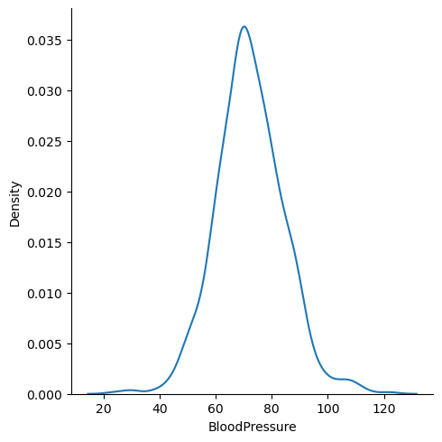

```python
# remove _____ & write the appropriate library name

sns.displot(pima['BloodPressure'], kind='kde')
plt.show()

# seaborn is used to display the distribution plot for the 'BloodPressure' variable. The (kind='kde') component of the code visualizes the data as a continuous probability density curve.

# Reference: course materials + https://seaborn.pydata.org/generated/seaborn.kdeplot.html
```

#### Write your Answer here:

Ans 10: This visual representation of blood pressure has a relatively normal distribution with a mean of 72.25 (derived from Q9). This figure shows that most levels of blood pressure remain between 40 and 100. In other words, most of the data does not deviate far from the mean. This plot also shows the density, which is at a peak of a little over 0.035.

## Q 11. What is the 'BMI' of the person having the highest 'Glucose'? (1 Mark)

```python
# remove _____ & write the appropriate function name

pima[pima['Glucose']==pima['Glucose'].max()]['BMI']

# In order to see the 'BMI' of the person with the highest 'Glucose', the max() function is added.

# Reference: https://www.geeksforgeeks.org/python-max-function/
```

```
661    42.9
Name: BMI, dtype: float64
```

#### Write your Answer here:

Ans 11: The 'BMI' of the person with the highest 'Glucose' is 42.9.

## Q12.

### 12.1 What is the mean of the variable 'BMI'?

### 12.2 What is the median of the variable 'BMI'?

### 12.3 What is the mode of the variable 'BMI'?

### 12.4 Are the three measures of central tendency equal?

### (3 Marks)

```python
# remove _____ & write the appropriate function name

m1 = pima['BMI'].mean()  # mean is calculated with the mean() function.
print(m1)
m2 = pima['BMI'].median()  # median is calculated with the median() function.
print(m2)
m3 = pima['BMI'].mode()[0]  # mode is calculated with the mode() function.
print(m3)

# Reference: course materials.
```

```
32.45080515543617
32.0
32.0
```

#### Write your Answer here:

Ans 12: The mean = ~32.45 ; the median = 32 ; the mode = 32. Yes, the three measures of central tendency are equal, relatively speaking. The mean differs by about 0.45 compared to the median and the mode; however, the three measures of central tendency are equal enough.

## Q13. How many women's 'Glucose' levels are above the mean level of 'Glucose'? (1 Mark)

```python
# remove _____ & write the appropriate function name

pima[pima['Glucose']>pima['Glucose'].mean()].shape[0]

# To find out how many women's 'Glucose' levels are above the mean level of 'Glucose', the mean() function is added.

# Reference: course materials.
```

```
343
```

#### Write your Answer here:

Ans 13: There are 343 women whose glucose levels are above the mean level of glucose.

## Q14. How many women have their 'BloodPressure' equal to the median of 'BloodPressure' and their 'BMI' less than the median of 'BMI'? (2 Marks)

```python
# remove _____ & write the appropriate column name

pima[(pima['BloodPressure']==pima['BloodPressure'].median()) & (pima['BMI']<pima['BMI'].median())]

# To find out how many women have their 'BloodPressure' equal to the median of 'BloodPressure', the median() function is added.
# To find out how many women have their 'BMI' less than the median of 'BMI', again the median() function is added.

# Reference: course materials.
```

|  | Pregnancies | Glucose | BloodPressure | SkinThickness | Insulin | BMI | DiabetesPedigreeFunction | Age | Outcome |
| --- | --- | --- | --- | --- | --- | --- | --- | --- | --- |
| 14 | 5 | 166 | 72 | 19 | 175 | 25.8 | 0.587 | 51 | 1 |
| 93 | 4 | 134 | 72 | 20 | 79 | 23.8 | 0.277 | 60 | 1 |
| 103 | 1 | 81 | 72 | 18 | 40 | 26.6 | 0.283 | 24 | 0 |
| 205 | 5 | 111 | 72 | 28 | 79 | 23.9 | 0.407 | 27 | 0 |
| 299 | 8 | 112 | 72 | 20 | 79 | 23.6 | 0.840 | 58 | 0 |
| 325 | 1 | 157 | 72 | 21 | 168 | 25.6 | 0.123 | 24 | 0 |
| 330 | 8 | 118 | 72 | 19 | 79 | 23.1 | 1.476 | 46 | 0 |
| 366 | 6 | 124 | 72 | 20 | 79 | 27.6 | 0.368 | 29 | 1 |
| 380 | 1 | 107 | 72 | 30 | 82 | 30.8 | 0.821 | 24 | 0 |
| 393 | 4 | 116 | 72 | 12 | 87 | 22.1 | 0.463 | 37 | 0 |
| 406 | 4 | 115 | 72 | 20 | 79 | 28.9 | 0.376 | 46 | 1 |
| 446 | 1 | 100 | 72 | 12 | 70 | 25.3 | 0.658 | 28 | 0 |
| 460 | 9 | 120 | 72 | 22 | 56 | 20.8 | 0.733 | 48 | 0 |
| 488 | 4 | 99 | 72 | 17 | 79 | 25.6 | 0.294 | 28 | 0 |
| 497 | 2 | 81 | 72 | 15 | 76 | 30.1 | 0.547 | 25 | 0 |
| 510 | 12 | 84 | 72 | 31 | 79 | 29.7 | 0.297 | 46 | 1 |
| 568 | 4 | 154 | 72 | 29 | 126 | 31.3 | 0.338 | 37 | 0 |
| 615 | 3 | 106 | 72 | 20 | 79 | 25.8 | 0.207 | 27 | 0 |
| 635 | 13 | 104 | 72 | 20 | 79 | 31.2 | 0.465 | 38 | 1 |
| 644 | 3 | 103 | 72 | 30 | 152 | 27.6 | 0.730 | 27 | 0 |
| 717 | 10 | 94 | 72 | 18 | 79 | 23.1 | 0.595 | 56 | 0 |
| 765 | 5 | 121 | 72 | 23 | 112 | 26.2 | 0.245 | 30 | 0 |

#### Write your Answer here:

Ans 14: There are 22 women who have their 'BloodPressure' equal to the median of 'BloodPressure' and their 'BMI' less than the median of 'BMI'.

## Q15. Create a pairplot for the variables 'Glucose', 'SkinThickness', and 'DiabetesPedigreeFunction'. Write your observations from the plot. (4 Marks)

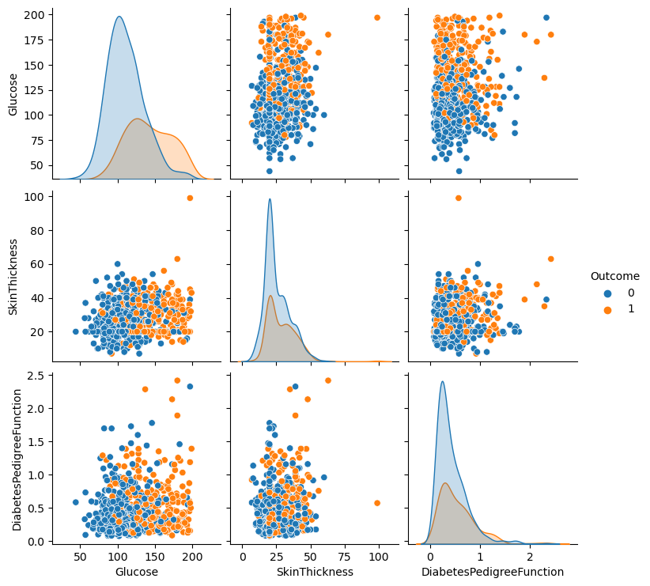

```python
# remove _____ & write the appropriate function name

sns.pairplot(data=pima,vars=['Glucose', 'SkinThickness', 'DiabetesPedigreeFunction'], hue='Outcome')
plt.show()

# To create a pairplot, the seaborn.pairplot() function is used. The 'hue' argument is added to categorize the variables into various colors. In this instance, the hue differentiates between types of 'Outcome'.

# Reference: course materials + https://www.geeksforgeeks.org/python-seaborn-pairplot-method/
```

#### Write your Answer here:

Ans 15: None of the plots indicate a relationship between the two variables. However, there seems to be a slight pattern in 'Outcome' for 'Glucose' levels across 'Diabetes Pedigree Function' and 'Skin Thickness'. Generally speaking, the higher the glucose the higher frequency of outcome 1, and the lower the glucose the more prevalence of outcome 0.

## Q16. Plot the scatterplot between 'Glucose' and 'Insulin'. Write your observations from the plot. (2 Marks)

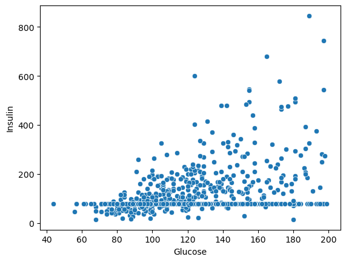

```python
# remove _____ & write the appropriate function name

sns.scatterplot(x = 'Glucose', y = 'Insulin', data=pima)
plt.show()

# To create a scatterplot, the seaborn.scatterplot() function is used. Within the function, 'x' and 'y' are identified as well is from where the data is derived (data=pima).

# Reference: https://seaborn.pydata.org/generated/seaborn.scatterplot.html
```

#### Write your Answer here:

Ans 16: There is a loose correlation between 'Glucose' and 'Insulin' in that the higher the glucose the higher the insulin. That being said, there is also a straight line between 0 - 200 levels of insulin. That is to say, no matter how much higher glucose levels rise, for some, insulin levels remain between 0 and 200.

## Q 17. Plot the boxplot for the 'Age' variable. Are there outliers? (2 Marks)

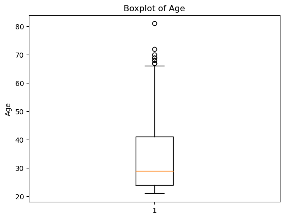

```python
# remove _____ & write the appropriate function and column name

plt.boxplot(pima['Age'])

plt.title('Boxplot of Age')
plt.ylabel('Age')
plt.show()

# To create a boxplot, the matplotlib.pyplot.boxplot() function is used. The title and ylabel are detailed as 'plt.title('Boxplot of Age')' and 'plt.ylabel('Age')', respectively.

# Reference: course materials + https://matplotlib.org/stable/api/_as_gen/matplotlib.pyplot.boxplot.html
```

#### Write your Answer here:

Ans 17: Yes, there are outliers, which are represented as dots. The outliers lie between ~ 65 years of age and older.

## Q18. Plot histograms for the 'Age' variable to understand the number of women in different age groups given whether they have diabetes or not. Explain both histograms and compare them. (3 Marks)

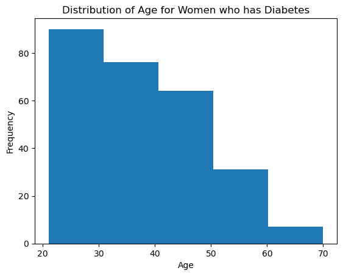

```python
# remove _____ & write the appropriate function and column name

plt.hist(pima[pima['Outcome']==1]['Age'], bins = 5)
plt.title('Distribution of Age for Women who has Diabetes')
plt.xlabel('Age')
plt.ylabel('Frequency')
plt.show()

# To create a histogram, the matplotlib.pyplot.hist() function is used. 'Age' was added as a variable.

# Reference: course materials + https://matplotlib.org/stable/api/_as_gen/matplotlib.pyplot.hist.html
```

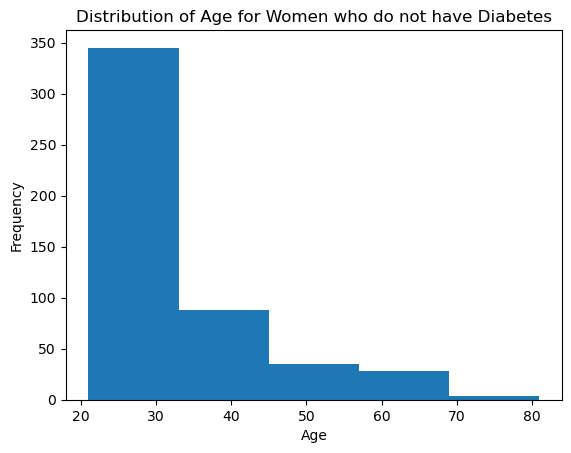

```python
# remove _____ & write the appropriate function and column name

plt.hist(pima[pima['Outcome']==0]['Age'], bins = 5)
plt.title('Distribution of Age for Women who do not have Diabetes')
plt.xlabel('Age')
plt.ylabel('Frequency')
plt.show()

# To create a histogram, the matplotlib.pyplot.hist() function is used. 'Age' was added as a variable.

# Reference: course materials + https://matplotlib.org/stable/api/_as_gen/matplotlib.pyplot.hist.html
```

#### Write your Answer here:

Ans 18: 1. The first histogram shows the Distribution of Age for Women who have Diabetes. The histogram indicates that the older the women the lower the level of prevalence of diabetes. There appears to be a gradual decline in frequency as the age of women increase. The highest frequency of women who do have diabetes are in their 20s. 2. The second histogram shows the Distribution of Age for Women who do not have Diabetes. The histogram indicates that the older the women the lower the frequency of women who do not have diabetes. There is a sharp decline in frequency as the age of women increases. The highest frequency of women who do not have diabetes are in their 20s. Comparison: Both histograms indicate a decline in frequency as the 'Age' increases. However, the second histogram has a sharper decline. Both histograms have the highest frequency for women who are in their 20s.

## Q 19. What is the Interquartile Range of all the variables? Why is this used? Which plot visualizes the same? (2 Marks)

```python
# remove _____ & write the appropriate variable name

Q1 = pima.quantile(0.25)
Q3 = pima.quantile(0.75)
IQR = Q3 - Q1
print(IQR)

# To plot the IQR, Q3 is subtracted by Q1.

# Reference: https://www.geeksforgeeks.org/interquartile-range-iqr/
```

```
Pregnancies                  5.0000
Glucose                     40.5000
BloodPressure               16.0000
SkinThickness               12.0000
Insulin                     48.2500
BMI                          9.1000
DiabetesPedigreeFunction     0.3825
Age                         17.0000
Outcome                      1.0000
dtype: float64
```

#### Write your Answer here:

Ans 19: The below listed are the IQR of all the variables: Pregnancies 5.0000 Glucose 40.5000 BloodPressure 16.0000 SkinThickness 12.0000 Insulin 48.2500 BMI 9.1000 DiabetesPedigreeFunction 0.3825 Age 17.0000 Outcome 1.0000 IQR is used to indicate at which range most of the data is located, which helps eliminate outliers from skewing the data. A plot that can visualize this is a boxplot, because it shows the quartiles of a dataset and indicates the outliers.

## Q 20. Find and visualize the correlation matrix. Write your observations from the plot. (3 Marks)

```python
# remove _____ & write the appropriate function name and run the code

corr_matrix = pima.iloc[:,0:8].corr()

corr_matrix

# In order to create a correlation matrix, the corr() method is used.

# Reference: course materials + https://www.geeksforgeeks.org/create-a-correlation-matrix-using-python/
```

|  | Pregnancies | Glucose | BloodPressure | SkinThickness | Insulin | BMI | DiabetesPedigreeFunction | Age |
| --- | --- | --- | --- | --- | --- | --- | --- | --- |
| Pregnancies | 1.000000 | 0.128022 | 0.208987 | 0.009393 | -0.018780 | 0.021546 | -0.033523 | 0.544341 |
| Glucose | 0.128022 | 1.000000 | 0.219765 | 0.158060 | 0.396137 | 0.231464 | 0.137158 | 0.266673 |
| BloodPressure | 0.208987 | 0.219765 | 1.000000 | 0.130403 | 0.010492 | 0.281222 | 0.000471 | 0.326791 |
| SkinThickness | 0.009393 | 0.158060 | 0.130403 | 1.000000 | 0.245410 | 0.532552 | 0.157196 | 0.020582 |
| Insulin | -0.018780 | 0.396137 | 0.010492 | 0.245410 | 1.000000 | 0.189919 | 0.158243 | 0.037676 |
| BMI | 0.021546 | 0.231464 | 0.281222 | 0.532552 | 0.189919 | 1.000000 | 0.153508 | 0.025748 |
| DiabetesPedigreeFunction | -0.033523 | 0.137158 | 0.000471 | 0.157196 | 0.158243 | 0.153508 | 1.000000 | 0.033561 |
| Age | 0.544341 | 0.266673 | 0.326791 | 0.020582 | 0.037676 | 0.025748 | 0.033561 | 1.000000 |

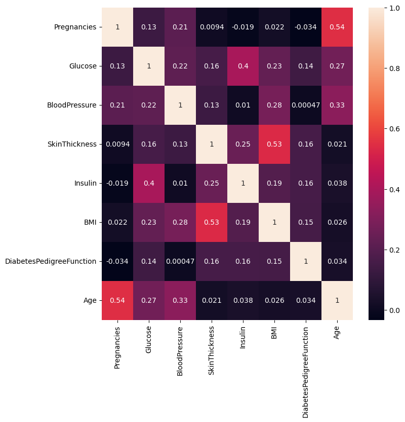

```python
# remove _____ & write the appropriate function name

plt.figure(figsize=(8,8))
sns.heatmap(corr_matrix, annot = True)

# display the plot
plt.show()

# Next, a heatmap is created using the seaborn.heatmap() function. The (annot = True) is used to annotate the heatmap, which means to include the data in the cells.

# Reference: course materials + https://seaborn.pydata.org/generated/seaborn.heatmap.html
```

#### Write your Answer here:

Ans 20: - The boxes with a '1' inside indicate the variables correlated with themselves. - The boxes with a negative number indicate a negative correlation, i.e., 'Pregnancies' and 'Diabetes Pedigree Function' as well as 'Pregnancies' and 'Insulin'. - There is a slight positive correlation between variables with a '0.54' and '0.53' number, i.e., 'Pregnancies' and 'Age' as well as 'BMI' and 'Skin Thickness'. - The other variables do not have a strong negative or positive correlation.